# Prediction of Patient Status using Voice Measurements

## Create an ROC Curve

1. Get a list of predictions (probability scores) using the predict() function

```r
library(ROCR)
prob_Resp=predict(logistic_model1,type = "response")
```

2. Using the ROCR package create a “prediction()” object

```r
predicted_resp=prediction(prob_Resp,trained_data$status)
```

3. Extract performance measures (True Positive Rate and False Positive Rate) using the “performance()” function from the ROCR package

```r
perf = performance(predicted_resp, measure="tpr", x.measure="fpr")
```

4. Plot the ROC curve using the extracted performance measures (TPR and FPR)

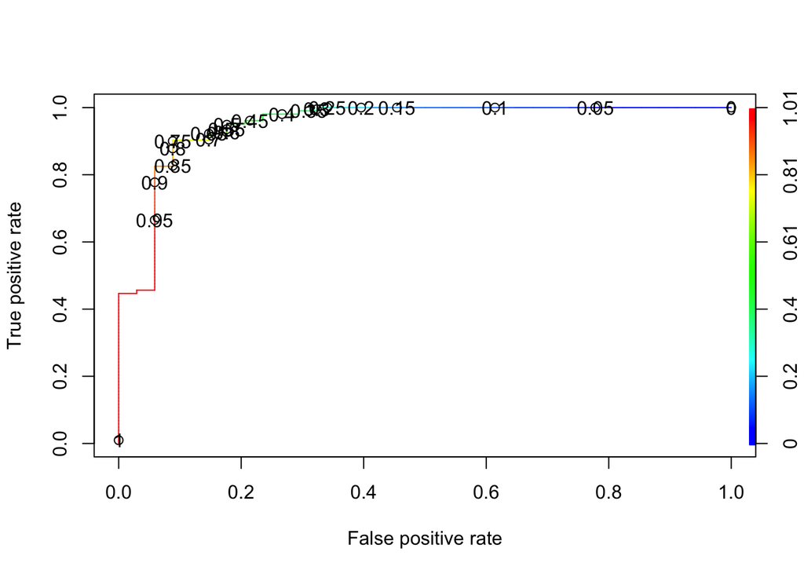

```r
plot(perf, col=rainbow(10), colorize=T, print.cutoffs.at=seq(0,1,.05))
```

- Extract the AUC score of the ROC curve and store it in a variable named “auc”

```r
performance_auc <- performance(predicted_resp, measure="auc")
# Access the auc score from the performance object
auc <- performance_auc@y.values[[1]]
print(auc)
```

```
## [1] 0.9505997
```

## Choose a Cutoff Value

- Based on the trade off between TPR and FPR depending on the business domain, a call on the cutoff has to be made.

```r
### Write your answer here
# A cutoff of ----- seems reasonable
#.1 or .05 seems to be reasonable for my assuption.
```

## Predictions on test data

- After choosing a cutoff value, predict the class labels on the test data using our model

```r
prob_test_Data=predict(logistic_model1, testing_data, type = "response")
preds_test=ifelse(prob_test_Data > 0.1, "Parkinson's", "Normal")
table(preds_test)
```

```
## preds_test
##      Normal Parkinson's
##           5          53
```

# Evaluation Metrics for classification

## Manual Computation

### Confusion Matrix

- Create a confusion matrix using the table() function

```r
Confusion_matrix=table(testing_data$status, preds_test)
print(Confusion_matrix)
```

```
##              preds_test
##               Normal Parkinson's
##   Normal           5           9
##   Parkinson's      0          44
```

### Specificity

- Calculate the Specificity
- The Proportion of correctly identified negatives by the test/model.

$${Specificity} = \frac{Number~of~True~Negatives}{Number~of~True~Negatives + Number~of~False~Positives}$$

```r
specificity <- Confusion_matrix[1, 1]/sum(Confusion_matrix[1, ])
print(specificity)
```

```
## [1] 0.3571429
```

### Sensitivity

- Calculate the Sensitivity
- The Proportion of correctly identified positives by the test/model.

$${Sensitivity} = \frac{Number~of~True~Positives}{Number~of~True~Positives + Number~of~False~Negatives}$$

```r
sensitivity <- Confusion_matrix[2, 2]/sum(Confusion_matrix[2, ])
print(sensitivity)
```

```
## [1] 1
```

### Accuracy

- Calculate the Accuracy
- The Proportion of correctly identified psotivies/negatives in the entire population by the test/model

$${Accuracy} = \frac{Number~of~True~Positives +Number~of~True~Negatives}{Number~Of~Subjects~in~the~Population}$$

```r
accuracy <- sum(diag(Confusion_matrix))/sum(Confusion_matrix)
print(accuracy)
```

```
## [1] 0.8448276
```

## Automated Computation through Caret

- Use the caret package to compute the evaluation metrics
- Mention your reference positive class as an argument to the confusionMatrix() function

```r
confusionMatrix(preds_test, testing_data$status, positive = "Parkinson's")
```

```
## Confusion Matrix and Statistics
##
##              Reference
## Prediction    Normal Parkinson's
##   Normal           5           0
##   Parkinson's      9          44
##
##                Accuracy : 0.8448
##                  95% CI : (0.7258, 0.9265)
##     No Information Rate : 0.7586
##     P-Value [Acc > NIR] : 0.079103
##
##                   Kappa : 0.4574
##  Mcnemar's Test P-Value : 0.007661
##
##             Sensitivity : 1.0000
##             Specificity : 0.3571
##          Pos Pred Value : 0.8302
##          Neg Pred Value : 1.0000
##              Prevalence : 0.7586
##          Detection Rate : 0.7586
##    Detection Prevalence : 0.9138
##       Balanced Accuracy : 0.6786
##
##        'Positive' Class : Parkinson's
##
```